# Module 7 Assignment

## Monte Carlo Simulation for Finance

In this assignment, we'll work through an example using Monte Carlo simulation for finance. We were introduced to the idea in a video on this module. In this notebook, we will work through a code example and see it in action!

**Learning objectives:**

- Understand when and why Monte Carlo simulation is used
- Run a toy simulation to estimate Pi
- Understand the benefits of simulation vs. a single calculation
- Be able to apply simulation to an investment problem

Recall that **simulation** is the approximation of the operation of a phenomenon of interest. That is, we use simulation to better understand a dynamic process by approximating how it might unfold. **Monte Carlo simulation** is a particular kind of simulation where we **repeat** a simulation many times, through **random sampling**, in order to understand a process that would otherwise be hard to solve.

We can use Monte Carlo simulation to understand the likelihood of certain outcomes from our process. [In finance](https://www.investopedia.com/articles/investing/112514/monte-carlo-simulation-basics.asp), that process might be something like how our portfolio will behave over time or to how to price options.

# 1) Estimating Pi using Monte Carlo methods

Before we apply Monte Carlo simulation to finance, let's get a feel for how Monte Carlo methods work. We'll be using them to estimate Pi ($\pi$), that reliable constant from geometry. Recall that $\pi$ is used in equations that relate the area and circumference of a circle. For example, the area of a circel is: $A_{circle} = \pi r^2$

A classical example for demonstrating Monte Carlo methods is to imagine we're trying to [estimate the numerical value of $\pi$](https://www.geeksforgeeks.org/estimating-value-pi-using-monte-carlo/). Assume we know the equation, but don't know the actual numerical value of $\pi$.

To estimate $\pi$, we might start with a square board and throw imaginary darts at it. We'll want to begin by throwing our darts in a **uniformly random** way. Let's set up the code.

```python
# run the import statements
import numpy as np
import matplotlib.pyplot as plt
```

```python
n = 1000 # number of observations

def random_x_and_y(n):
    np.random.seed(42) # set random seed
    x = np.random.uniform(-1, 1, size=[n, 1])
    y = np.random.uniform(-1, 1, size=[n,1])

    return x,y
```

```python
# TODO create variables x and y to receive the outcome from using the random number generating function above
# Use n = 1000, which is the default value if you don't specify an n

x, y = random_x_and_y(n)
```

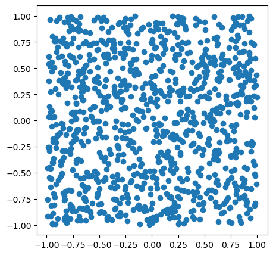

```python
# TODO use a scatter plot and plot the (x,y) pairs obtained above
# use plt.scatter(..., ...)
# use plt.figure(figsize = [5,5]); before you plot the scatter to make the figure a true square

plt.figure(figsize = [5,5]);
plt.scatter(x, y);
```

We can then set up this ratio: $$\frac{\text{area of circle}}{\text{area of square}} = \frac{\text{number of randomly generated points inside circle}}{\text{number of randomly generated points inside square}} $$

Then,

$$ \frac{\text{area of circle}}{\text{area of square}} = \frac{\pi r^2}{(2r)^2} = \frac{\pi r^2}{4(r^2)}$$

We can solve for $\pi$:

$$ \pi = 4* \frac{\text{area of circle}}{\text{area of square}}$$

To estimate $\pi$, we can look at our randomly generated points and check whether they're inside of the circle or not. Then we can divide the number of points inside the circle by all points, and multiply by 4 to *estimate* $\pi$. Note that we're estimating $\pi$, not calculating the exact value. That is the heart of **simulation**, which uses algorithms such as this one to estimate values that might be too hard to calculate exactly otherwise.

We can check **whether a point is inside of the circle** by checking whether $x^2 + y^2 \leq 1$. We can then count up the points inside the circle and divide by the total points.

```python
# run this cell

inside_circle = (x**2 + y**2) <= 1
x_inside = x[inside_circle]
y_inside = y[inside_circle]
```

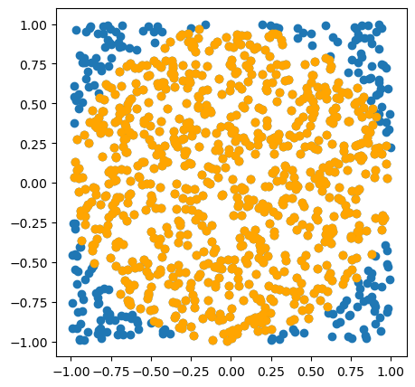

```python
# TODO use the helper function above to plot all the points inside and outside the circle
# this time, color the points inside the circle in a different color
# to do this, first plot the scatter of all points
# then plot the scatter of the x_inside, y_inside points and give them a color different from the default blue

plt.figure(figsize = [5,5]);
plt.scatter(x, y )
plt.scatter(x_inside, y_inside, c = 'orange');
```

We can estimate $\pi$ by using our formula from above. In code below:

```python
# run this cell and compare your estimated pi to the actual value (3.14)

# recall we set n above and it's the total number of points we've sampled

estimated_pi = 4 * (inside_circle.sum()/ n)
print("Estimate pi = ", estimated_pi)
```

```
Estimate pi =  3.096
```

We've estimated $\pi$ as 3.096, which is close to but not exactly 3.14. So how can we do better? We can increase the number of random points we sample. Above we set n=1000, but try setting it to something higher and retry the analysis. You can copy/paste code from above as needed.

See if you can get your output to look like this:

[figure not shown]

```
Estimate pi =  3.14412
```

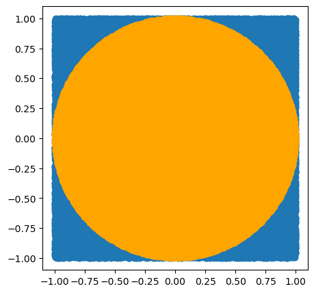

```python
# TODO try the above analysis with n set to something higher than 1000
# Try it several times with increasing values! Use the code from above

n = 100000
x,y = random_x_and_y(n)

inside_circle = (x**2 + y**2) <= 1
x_inside = x[inside_circle]
y_inside = y[inside_circle]

plt.figure(figsize = [5,5]);
plt.scatter(x, y)
plt.scatter(x_inside, y_inside, c = 'orange');

estimated_pi = 4 * (inside_circle.sum()/ n)
print("Estimate pi = ", estimated_pi)
```

## 2) Monte Carlo methods in finance

We will now use the Monte Carlo simulation method from above to simulate a portfolio return. We need to know a few things:

- The annual return rate of our portfolio
- The volatility of the return, measured in the standard deviation of the portfolio
- How much investment we're adding each year

Assume our strategy is to use to a [systematic investment plan](https://www.investopedia.com/terms/s/systematicinvestmentplan.asp), where we add a fixed amount of new investment every year. This way, we can grow our portfolio slowly over time and take advantage of compounding and [dollar-cost averaging](https://www.investopedia.com/terms/d/dollarcostaveraging.asp) to reduce the negative impact volatility can have on our investment over a long time horizon.

```python
import pandas as pd
```

```python
# run this cell to set up our conditions
starting_investment = 10000
yearly_investment = 10000
expected_r = 0.07
volatility = 0.12

# We also need to know the duration of our investment. Let's assume 10 years.
years = 10
```

## 2a) Run the simulation one time

Let's now run through our simulation **one time** to see what happens to our investment after 10 years. This is not a Monte Carlo simulation yet as we're only running through it once! Recall that a Monte Carlo simulation is better than a single simulation because it involves running through our model multiple times, refreshing our random variables each time, and looking at a summary statistic. We'll get to the Monte Carlo version in the next step, so hold on!

```python
# run this cell to set up the helper function

def calculate_returns(starting_investment, yearly_investment, expected_r, volatility, years):
    total_investment = starting_investment

    for year in range(years):
        market_return = np.random.normal(expected_r, volatility)
        ending_value = yearly_investment + (1+ market_return)* total_investment
        print("Year ", year+1, ": return = ", market_return, " and year-end value = ", f"{ending_value:,.0f}")
        total_investment = ending_value
```

```python
# TODO use the helper function above to calculate 10 year returns for one simulation
# try running this cell multiple times to see how the outputs change!

calculate_returns(starting_investment, yearly_investment, expected_r, volatility, years)
```

```
Year  1 : return =  0.02954104409103553  and year-end value =  20,295
Year  2 : return =  -0.1428639423888305  and year-end value =  27,396
Year  3 : return =  0.05545332372453627  and year-end value =  38,915
Year  4 : return =  -0.03966433773919166  and year-end value =  47,372
Year  5 : return =  -0.008605799961277721  and year-end value =  56,964
Year  6 : return =  -0.0349417052086793  and year-end value =  64,973
Year  7 : return =  0.19132921721879742  and year-end value =  87,405
Year  8 : return =  0.06312560004982783  and year-end value =  102,922
Year  9 : return =  0.034124930441157095  and year-end value =  116,435
Year  10 : return =  0.07583180907795184  and year-end value =  135,264
```

**Student exercise**: What do you notice about the returns above? How much do you have after 10 years with a starting investment of 10k, yearly 10k additional investment, a return of 7% with a volatility of 12% standard deviation?

- The returns are calculating the compounded interest rate return of the investment which grew to 135k by year 10 benefited by the coumpounded interest.

## 2b) Monte Carlo simulation of portfolio returns

Above we ran the simulation once. We will now run a Monte Carlo simulation, and run the simulation multiple times and look at aggregate statistics to better understand what may happen to our returns over time.

We will set $n$ to be the number of times we run the simulation. Every run of n is one simulation, like we saw above. Start with n=5 and then try again with n=500 to see how the outputs differ.

```python
# TODO set the number of runs of our Monte Carlo simulation
# start with 5, then try 500

n = 500
```

```python
# run this cell for the helper function

def run_monte_carlo(n, starting_investment, yearly_investment, expected_r, volatility, years):
    returns_list = []

    for _ in range(n):
        total_investment = starting_investment
        returns = []

        for year in range(years):
            market_return = np.random.normal(expected_r, volatility)
            ending_value = yearly_investment + (1 + market_return) * total_investment
            total_investment = ending_value
            returns.append(total_investment)

        returns_list.append(returns)

    returns_df = pd.DataFrame(returns_list, columns=["y1","y2","y3","y4","y5","y6","y7","y8","y9","y10"])
    return returns_df
```

```python
# TODO use the run_monte_carlo() function above and set the output to a dataframe
# take a look at .head(5) of the resulting dataframe

returns_df = run_monte_carlo(n, starting_investment, yearly_investment, expected_r, volatility, years)

print(returns_df.head(5))
```

```
             y1            y2            y3            y4            y5  \
0  22555.629404  32458.507166  46682.307969  67184.454048  87660.764410
1  20281.757913  29578.218295  37297.241500  44785.069693  62371.719822
2  20868.244862  31397.605706  41010.860899  50784.985779  65534.941027
3  20134.880556  36046.350921  46171.170094  55365.889062  54888.666690
4  19998.188257  32965.360979  42647.064080  49718.365948  66053.157575

              y6             y7             y8             y9            y10
0  112400.348632  112172.217490  138088.157384  170193.105872  205806.961652
1   58004.601772   72516.323867   82229.714180  104908.938260  138270.230753
2   77473.184100   89002.153649  122488.649501  136517.656265  144881.371156
3   72983.110937   99057.537100  116815.510518  134886.418101  149607.050285
4   81636.100842   83019.270595  102075.742732  138075.360887  167946.595966
```

**Student exercise**: What do you notice about the returns over each year, and over each run of the simulation?

- There is variation within each observation of year 10 so if I am printing 500 observations I am printing a normal distribution of results with an average, min, max, and standard deviations.
- I can also see what would be the 20th percentile, 5th percentile, 50th percentile(most likely), and 80% percentile to get an idea of what are my limits of the monte carlo calculation of NPV.

## 2c) Calculate summary statistics of Monte Carlo simulation

In the above step, we ran our Monte Carlo simulation 500 times. The point of such simulation is to then take a look at the summary statistics. These summary statitics -- for example, the mean of returns after year 10 -- will be more accurate than a single run of the simulation, as we did in step 2a.

The mean of 500 runs is better than one run because each run has a random component. A mean of many random runs is more accurate because a single run could have been really high or really low, just by chance.

```python
# run the following cell to see some summary stats

print("The MEAN ending investment after 10 years = ", f"{returns_df['y10'].mean():,.0f}")
```

```
The MEAN ending investment after 10 years =  158,919
```

```python
# TODO use the above line of code as an example and return other summary statistics, e.g.
# MIN return after 10 years
# MAX return after 10 years
# STANDARD DEVIATION of 10 year return

print("The MAX ending investment after 10 years = ", f"{returns_df['y10'].max():,.0f}")

print("The MIN ending investment after 10 years = ", f"{returns_df['y10'].min():,.0f}")

print("The STD DEV ending investment after 10 years = ", f"{returns_df['y10'].std():,.0f}")
```

```
The MAX ending investment after 10 years =  321,189
The MIN ending investment after 10 years =  88,247
The STD DEV ending investment after 10 years =  33,876
```

Another way to see the output of the 500 simulations is to plot a histogram of the ending 10-year return. Run the following cell to see it!

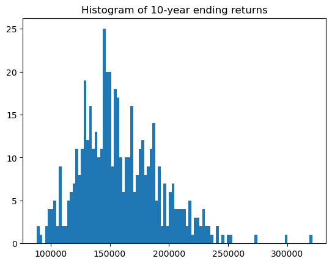

```python
# run this cell

plt.hist(returns_df[['y10']], bins = 100)
plt.title("Histogram of 10-year ending returns");
```

**Student exercise**: What do you notice about the shape of the returns? How does this relate to our input?

- We have a normal distribution that is skewed to the right, so positively skewed. We probably should not rely on the outliers within min and max and should try to take in values within 1 or 2 standard deviations to make projections.

One more statistic: what's the probability of our total investment being more than 200,000 dollars after 10 years?

```python
returns_gt_200k = len(returns_df[returns_df['y10']>=200000])/len(returns_df)
print("Probability of total investment >= 200k after 10 years = ", returns_gt_200k*100, "%")
```

```
Probability of total investment >= 200k after 10 years =  12.4 %
```

```python
# TODO try it for another cutoff

returns_gt_300k = len(returns_df[returns_df['y10']>= 300000 ])/len(returns_df)
print("Probability of total investment >= 300k after 10 years = ", returns_gt_300k*100, "%")
```

```
Probability of total investment >= 300k after 10 years =  0.2 %
```

**Student exercise**: Use the above code to try calculating the probability at other cutoffs!

**Summary**: What did we notice from running the Monte Carlo simulation? What other information did it give us beyond running only a single simulation run? Which would you trust more?

- We should trust more a robust number of simulations, if we only have 5 simulations we can't create a normal distribution which would help us predict the likelihood of each outcome with precision. This is why we ran 500 simulations.
- If we ran 5 or 10 simulations out output would likely give us a very skewed distribution which wouldn't be normal, thus having high skewness and curtosis, thus the mean, median, mode, min, max, and percentiles lose value.